# Table of Contents

## Minería de Datos (Master en Data Science, UIMP-UC)

## Tarea 1. Variables Categóricas: Reglas de Asociación y Árboles de Clasificación

### [Profesores: Joaquín Bedia, Rodrigo García, Ana Casanueva y Sixto Herrera]

En la presente tarea consideraremos el dataset `Mushroom`, incluido tanto en la La librería [arulesViz](https://cran.r-project.org/web/packages/arulesViz/arulesViz.pdf) como en las diferentes plataformas descritas en el marco de la asignatura y en el GitHub dedicado a este Máster ([Mushroom](https://github.com/SantanderMetGroup/Master-Data-Science/blob/master/Data_mining/datasets/mushrooms.csv.)), para aplicar las diferentes técnicas vistas en el curso para variables categóricas: Reglas de Asociación y Árboles de Clasificación.

Para el desarrollo de la tarea se permitirá el uso de todo el material incluido en el Moodle de las asignatura así como el desarrollado por el/la alumn@ durante la realización de las prácticas.

La entrega consisitirá de un notebook de Jupyter ó un R-MarkDown, junto con el archivo html que éste genera. Ambos ficheros se entregarán a través del Moodle de la asignatura en la tarea correspondiente.

### Punto 1 (3 puntos):

Considerar uno de los algoritmos de asociación vistos en clase y obtener las reglas representativas del dataset fijando los parámetros de aprendizaje (soporte, confianza, etc...). Analizar los resultados en términos generales:

- ¿Cuantas reglas se han generado?
- ¿Existe alguna regla redundante?, ¿Cuántas?
- ¿Existe alguna regla que incluya la variable objetivo: `Class=edible` ó `Class=poisonous`?, ¿Cuantas?
- De cara a ser utilizada como modelo predictivo es adecuado que la variable objetivo se encuentre en el consecuente de la regla de asociación, ¿se da esta propiedad en alguna regla?
- Considerar los subconjuntos de reglas con ambas clases como consecuente e ilustrar las variables implicadas en cada caso. Considerar alguno de los grafos vistos para apoyar las conclusiones obtenidas.

NOTA: Usar soportes superiores a 0.1 para evitar problemas de memoria.

## -------------------------------------------------------------------------------------

```r
library(arules)
library(arulesViz)
```

```r
# Dataset upload
data("Mushroom", package = "arules")
ds = Mushroom
summary(ds)
```

```
transactions as itemMatrix in sparse format with
 8124 rows (elements/itemsets/transactions) and
 114 columns (items) and a density of 0.1925851

most frequent items:
 VeilType=partial   VeilColor=white GillAttached=free    RingNumber=one
             8124              7924              7914              7488
  GillSpace=close           (Other)
             6812            140098

element (itemset/transaction) length distribution:
sizes
  21   22   23
2312 3868 1944

   Min. 1st Qu.  Median    Mean 3rd Qu.    Max.
  21.00   21.00   22.00   21.95   22.00   23.00

includes extended item information - examples:
           labels variables    levels
1    Class=edible     Class    edible
2 Class=poisonous     Class poisonous
3   CapShape=bell  CapShape      bell
```

## 1.1 and 1.2 using with ECLAT algorithm (APRIORI in comments just in case)

### APRIORI algorithm

```r
#rApriori <- apriori(ds, parameter = list(supp = 0.1, conf = 0, target = "rules", minlen = 2, maxlen=ncol(ds)))
#inspect(head(sort(rApriori, by = "lift"), 10))
```

```r
#rApriori_number <- length(rApriori) # Total number of rules
#rApriori_redundant <- is.redundant(rApriori) # Identify redundant rules
#rApriori_pruned <- rApriori[!rApriori_redundant] # Remove redundant rules
#rApriori_percentage <- 100 * sum(rApriori_redundant) / rApriori_number # Calculate the percentage of redundant rules

#cat("Number of rules:", rApriori_number, "\n")
#cat("Number of redundant rules:", sum(rApriori_redundant), "\n")
#cat("Number of pruned rules:", length(rApriori_pruned), "\n")
#cat("Percentage of redondant rules:", round(rApriori_percentage), "%", "\n")
```

### ECLAT algorithm

```r
iEclat <- eclat(ds, parameter = list(support = 0.1, tidLists = TRUE))
```

```
Eclat

parameter specification:
 tidLists support minlen maxlen            target  ext
     TRUE     0.1      1     10 frequent itemsets TRUE

algorithmic control:
 sparse sort verbose
      7   -2    TRUE

Absolute minimum support count: 812

create itemset ...
set transactions ...[114 item(s), 8124 transaction(s)] done [0.01s].
sorting and recoding items ... [53 item(s)] done [0.00s].
creating bit matrix ... [53 row(s), 8124 column(s)] done [0.00s].
writing  ... [340050 set(s)] done [3.15s].
Creating S4 object  ... done [2.20s].
```

```r
# Deduce association rules
rEclat <- ruleInduction(iEclat, ds, confidence = 0, control = list(method = "ptree", reduce = TRUE))
#inspect(head(sort(rEclat, by = "support"), 10))
```

```r
rEclat_number <- length(rEclat)
rEclat_redundant <- is.redundant(rEclat)
rEclat_pruned <- rEclat[!is.redundant(rEclat)]
rEclat_percentage <- 100 * sum(rEclat_redundant) / rEclat_number

cat("Number of rules:", rEclat_number, "\n")
cat("Number of redundant rules:", sum(rEclat_redundant), "\n")
cat("Number of pruned rules:", length(rEclat_pruned), "\n")
cat("Percentage of redondant rules:", round(rEclat_percentage), "%", "\n")
```

```
Number of rules: 2540554
Number of redundant rules: 2522918
Number of pruned rules: 17636
Percentage of redondant rules: 99 %
```

## 1.3 Rules with target variables

```r
#rApriori_edible <- subset(rApriori_pruned, rhs %in% "Class=edible")
#rApriori_poisonous <- subset(rApriori_pruned, rhs %in% "Class=poisonous")

#cat("Number of rules where the consequent is Class = edible:", length(rApriori_edible), "\n")
#cat("Number of rules where the consequent is Class = poisonous:", length(rApriori_poisonous), "\n")
```

```r
rEclat_edible <- subset(rEclat_pruned, rhs %in% "Class=edible")
rEclat_poisonous <- subset(rEclat_pruned, rhs %in% "Class=poisonous")

cat("Number of rules where the consequent is Class = edible:", length(rEclat_edible), "\n")
cat("Number of rules where the consequent is Class = poisonous:", length(rEclat_poisonous), "\n")
```

```
Number of rules where the consequent is Class = edible: 458
Number of rules where the consequent is Class = poisonous: 299
```

## 1.4 Predictive model

This means that there are association rules where the target variables `Class=edible` and `Class=poisonous` are in the consequent, making these rules suitable for use as a predictive model in both cases.

## 1.5 Visualization

```r
rEclat_classes <- c(rEclat_edible, rEclat_poisonous)
```

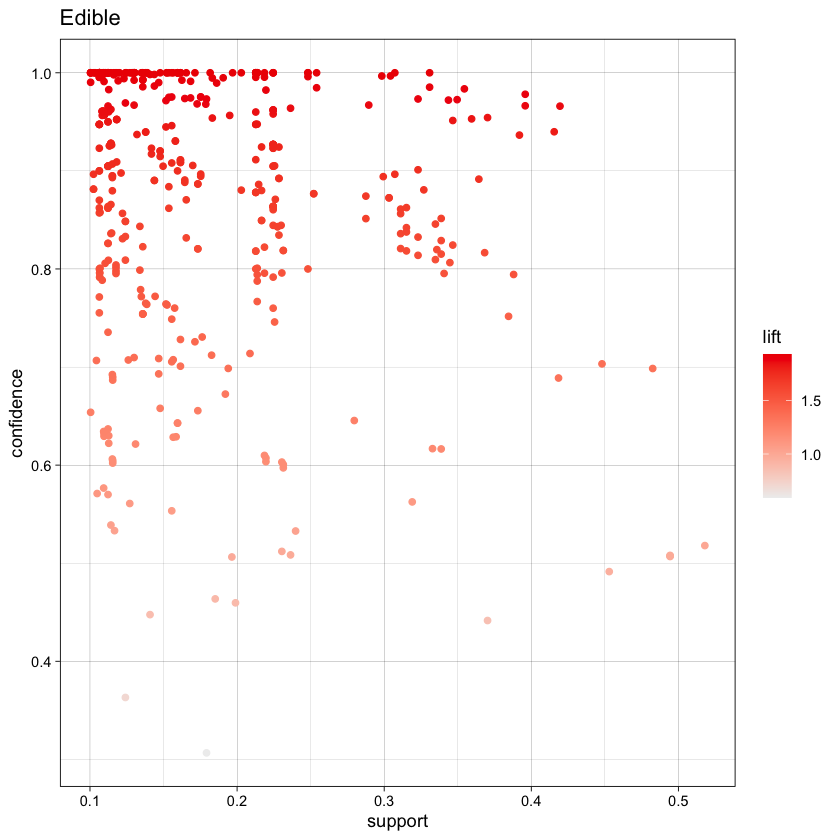

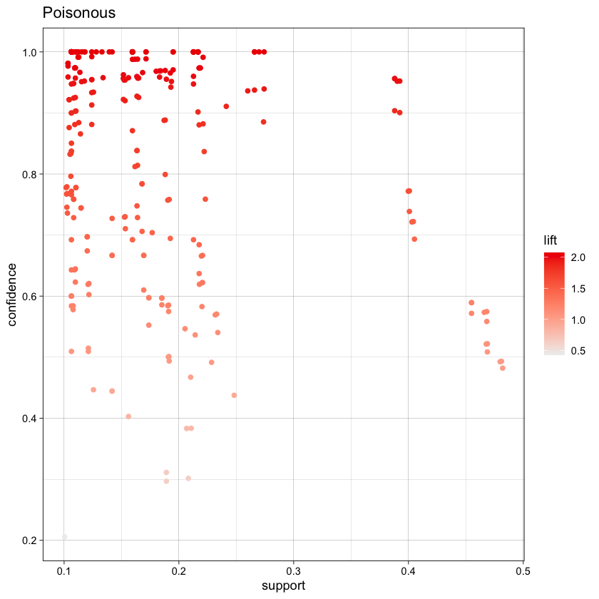

```r
plot(rEclat_edible, main="Edible", jitter = 0)
plot(rEclat_poisonous, main="Poisonous", jitter = 0)
```

Comments about both polts:

- Many points are located near the top of the plot, with confidence values close to 1. These rules are very reliable for predicting that a mushroom is edible or poisonous when the LHS conditions are met.
- Most rules have a support between 0.1 and 0.3, with a few reaching higher support levels, up to around 0.5. Higher support rules are more general and cover a significant portion of the dataset.
- Darker points, representing rules with a lift greater than 1.5, are generally located near the top of the plot. These rules are both reliable (high confidence) and significant (high lift). However, they often have moderate support, meaning they may not be the most frequent but are still highly interesting.
- In the lower left of the plot, there are points with low support (around 0.1) and confidence below 0.6. These rules are less frequent and less reliable, making them less relevant for predicting edible mushrooms.

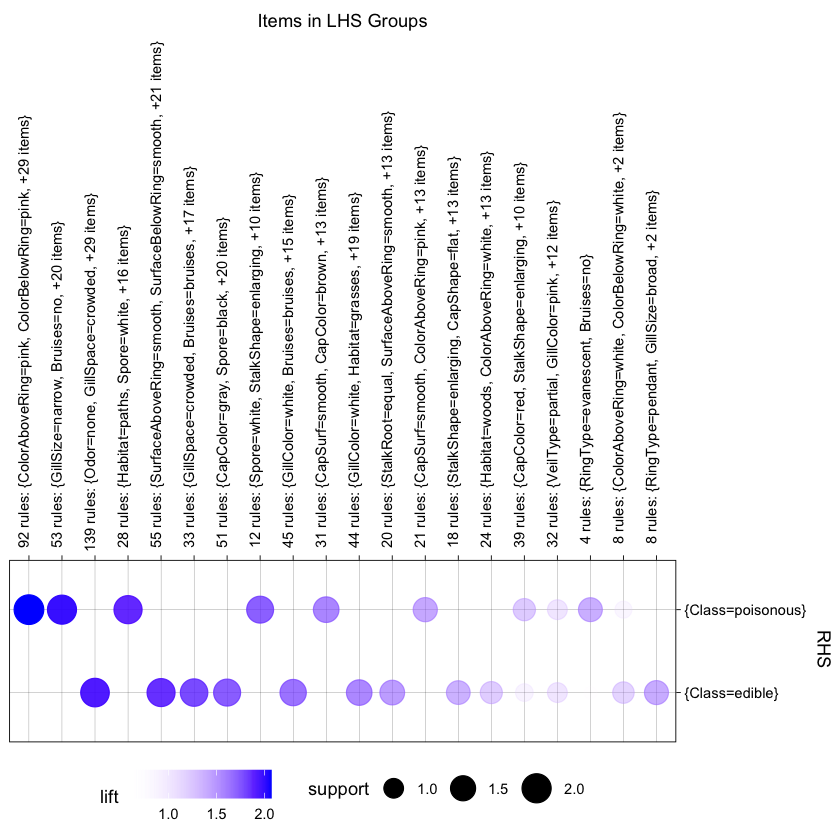

```r
plot(rEclat_classes, method="grouped", measure="lift", col="blue")
#plot(rEclat_classes, method="grouped", measure="support")
#plot(rEclat_classes, method="grouped", measure="confidence")
```

The vertical axis represents the RHS, indicating the predicted outcome: whether mushrooms are poisonous or edible. The size of each circle corresponds to the rule’s support, representing how frequently the combination of attributes occurs in the dataset. The color intensity represents lift, with darker circles indicating stronger and more meaningful associations.

To conclude, the subsets of rules for both classes (Class=edible and Class=poisonous) highlight distinct and sometimes overlapping features that define the classification. The graphical visualizations effectively illustrate these relationships, showing how different attributes contribute to predicting whether mushrooms are edible or poisonous.

## -------------------------------------------------------------------------------------

### Punto 2 (4 puntos):

En este apartado aplicaremos árboles de clasificación para obtener un modelo que permita clasificar una nueva entrada. Para ello, vamos a utilizar el paquete `CaReT`. Este paquete (y los demás que hemos visto para trabajar con árboles en `R`) no aceptan objetos del tipo `transactions` como los del apartado anterior. Por tanto, hemos preparado un fichero *csv* con el dataset *Mushrooms*; puedes descargarlo desde esta aquí: https://github.com/SantanderMetGroup/Master-Data-Science/tree/master/Data_mining/datasets. Puedes leer este dataset con la función `read.csv`.  
Ahora ya tenemos un data.frame con el que podemos empezar a trabajar. En primer lugar tendremos que eliminar la columna 17 (`veil.type`), ya que contiene un único nivel y daría errores en `CaReT`(esta columna podría eliminarse también en el caso de las reglas de asociación ya que no aporta información al dataset).  
Nuestro objetivo será encontrar la configuración (profundidad) óptima del árbol. Para ello, dividiremos el dataset en dos subconjuntos indpendedientes de train y test (75% y 25% del total, respectivamente). Sobre el dataset de train, aplicaremos una cross-validación con 3 folds y la repetiremos 50 veces (recuerda que los árboles son sensibles a la partición train/test que se considere).

- ¿Cuál es la configuración óptima del árbol? ¿Hay alguna diferencia entre el árbol *completo* y el óptimo? ¿Por qué crees que ocurre esto?
- ¿Cuáles son las dos variables que mayor peso tienen a la hora de clasificar? Entrena un nuevo árbol considerando como predictores únicamente esas dos variables. ¿Qué resultados obtienes?
- Entrena un nuevo árbol considerando como predictores cualesquiera otras dos variables que no sean las utilizadas en la pregunta anterior. ¿Cuál es el error de test de este árbol?

```r
library(caret)
library(rpart)
library(tree)
library(rpart.plot)
library(dplyr)
```

```r
mushrooms <- read.csv("mushrooms.csv")
head(mushrooms)
```

A data.frame: 6 x 23

|  | class <chr> | cap.shape <chr> | cap.surface <chr> | cap.color <chr> | bruises <chr> | odor <chr> | gill.attachment <chr> | gill.spacing <chr> | gill.size <chr> | gill.color <chr> | ... | stalk.surface.below.ring <chr> | stalk.color.above.ring <chr> | stalk.color.below.ring <chr> | veil.type <chr> | veil.color <chr> | ring.number <chr> | ring.type <chr> | spore.print.color <chr> | population <chr> | habitat <chr> |
| --- | --- | --- | --- | --- | --- | --- | --- | --- | --- | --- | --- | --- | --- | --- | --- | --- | --- | --- | --- | --- | --- |
| 1 | p | x | s | n | t | p | f | c | n | k | ... | s | w | w | p | w | o | p | k | s | u |
| 2 | e | x | s | y | t | a | f | c | b | k | ... | s | w | w | p | w | o | p | n | n | g |
| 3 | e | b | s | w | t | l | f | c | b | n | ... | s | w | w | p | w | o | p | n | n | m |
| 4 | p | x | y | w | t | p | f | c | n | n | ... | s | w | w | p | w | o | p | k | s | u |
| 5 | e | x | s | g | f | n | f | w | b | k | ... | s | w | w | p | w | o | e | n | a | g |
| 6 | e | x | y | y | t | a | f | c | b | n | ... | s | w | w | p | w | o | p | k | n | g |

```r
# Drop column 17
mushrooms$veil.type <- NULL

# Convert all character columns to factors
mushrooms[,1:ncol(mushrooms)] <- lapply(mushrooms[,1:ncol(mushrooms)], as.factor)

str(mushrooms)
```

```
'data.frame':	8124 obs. of  22 variables:
 $ class                   : Factor w/ 2 levels "e","p": 2 1 1 2 1 1 1 1 2 1 ...
 $ cap.shape               : Factor w/ 6 levels "b","c","f","k",..: 6 6 1 6 6 6 1 1 6 1 ...
 $ cap.surface             : Factor w/ 4 levels "f","g","s","y": 3 3 3 4 3 4 3 4 4 3 ...
 $ cap.color               : Factor w/ 10 levels "b","c","e","g",..: 5 10 9 9 4 10 9 9 9 10 ...
 $ bruises                 : Factor w/ 2 levels "f","t": 2 2 2 2 1 2 2 2 2 2 ...
 $ odor                    : Factor w/ 9 levels "a","c","f","l",..: 7 1 4 7 6 1 1 4 7 1 ...
 $ gill.attachment         : Factor w/ 2 levels "a","f": 2 2 2 2 2 2 2 2 2 2 ...
 $ gill.spacing            : Factor w/ 2 levels "c","w": 1 1 1 1 2 1 1 1 1 1 ...
 $ gill.size               : Factor w/ 2 levels "b","n": 2 1 1 2 1 1 1 1 2 1 ...
 $ gill.color              : Factor w/ 12 levels "b","e","g","h",..: 5 5 6 6 5 6 3 6 8 3 ...
 $ stalk.shape             : Factor w/ 2 levels "e","t": 1 1 1 1 2 1 1 1 1 1 ...
 $ stalk.root              : Factor w/ 5 levels "?","b","c","e",..: 4 3 3 4 4 3 3 3 4 3 ...
 $ stalk.surface.above.ring: Factor w/ 4 levels "f","k","s","y": 3 3 3 3 3 3 3 3 3 3 ...
 $ stalk.surface.below.ring: Factor w/ 4 levels "f","k","s","y": 3 3 3 3 3 3 3 3 3 3 ...
 $ stalk.color.above.ring  : Factor w/ 9 levels "b","c","e","g",..: 8 8 8 8 8 8 8 8 8 8 ...
 $ stalk.color.below.ring  : Factor w/ 9 levels "b","c","e","g",..: 8 8 8 8 8 8 8 8 8 8 ...
 $ veil.color              : Factor w/ 4 levels "n","o","w","y": 3 3 3 3 3 3 3 3 3 3 ...
 $ ring.number             : Factor w/ 3 levels "n","o","t": 2 2 2 2 2 2 2 2 2 2 ...
 $ ring.type               : Factor w/ 5 levels "e","f","l","n",..: 5 5 5 5 1 5 5 5 5 5 ...
 $ spore.print.color       : Factor w/ 9 levels "b","h","k","n",..: 3 4 4 3 4 3 3 4 3 3 ...
 $ population              : Factor w/ 6 levels "a","c","n","s",..: 4 3 3 4 1 3 3 4 5 4 ...
 $ habitat                 : Factor w/ 7 levels "d","g","l","m",..: 6 2 4 6 2 2 4 4 2 4 ...
```

```r
# Split the data into training and test sets, 75% and 25% respectively
n = nrow(mushrooms)
set.seed(3)
indtrain = sample(1:n, round(0.75 * n))
indtest = setdiff(1:n, indtrain)

mushrooms.train = mushrooms[indtrain, ]
mushrooms.test = mushrooms[indtest, ]
```

## 2.1 Optimal configuration

```r
# Define cross-validation parameters
trctrl <- trainControl(method = "repeatedcv", number=3, repeats=50)

# Train the classification tree model
trainedTree <- caret::train(
  class ~ .,
  data = mushrooms.train,
  method = "rpart2",
  trControl = trctrl,
  tuneLength = 10,
)
```

```r
optPred <- predict(trainedTree, newdata = mushrooms.test[, -1])
confMatrix <- confusionMatrix(optPred, mushrooms.test$class)
print(confMatrix)
```

```
Confusion Matrix and Statistics

          Reference
Prediction    e    p
         e 1059   25
         p   13  934

               Accuracy : 0.9813
                 95% CI : (0.9744, 0.9867)
    No Information Rate : 0.5278
    P-Value [Acc > NIR] : < 2e-16

                  Kappa : 0.9624

 Mcnemar's Test P-Value : 0.07435

            Sensitivity : 0.9879
            Specificity : 0.9739
         Pos Pred Value : 0.9769
         Neg Pred Value : 0.9863
             Prevalence : 0.5278
         Detection Rate : 0.5214
   Detection Prevalence : 0.5337
      Balanced Accuracy : 0.9809

       'Positive' Class : e
```

1059 mushrooms were correctly predicted as edible and 934 were correctly predicted as poisonous, while 38 were wrongly predicted. The total number of incorrect predictions is 38 out of 2031 samples, giving the model an overall error rate of approximately 1.87%.

The model demonstrates excellent performance, with high accuracy, sensitivity, and specificity.

```r
optTree <- trainedTree$finalModel
```

```
CART

6093 samples
  21 predictor
   2 classes: 'e', 'p'

No pre-processing
Resampling: Cross-Validated (3 fold, repeated 50 times)
Summary of sample sizes: 4062, 4062, 4062, 4062, 4063, 4061, ...
Resampling results across tuning parameters:

  maxdepth  Accuracy   Kappa
   1        0.8882326  0.7773377
   2        0.9462138  0.8924301
   3        0.9691713  0.9382631
   4        0.9783589  0.9566860
   5        0.9849172  0.9698016
   6        0.9849007  0.9697690
   7        0.9849007  0.9697690
   8        0.9849007  0.9697690
   9        0.9849007  0.9697690
  11        0.9849007  0.9697690

Accuracy was used to select the optimal model using the largest value.
The final value used for the model was maxdepth = 5.
```

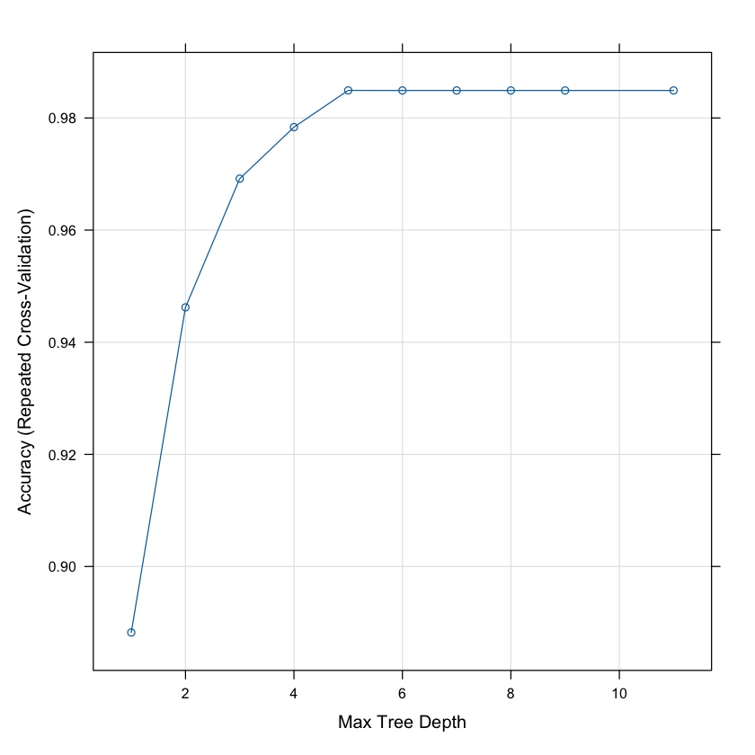

```r
print(trainedTree)
plot(trainedTree)
```

```r
fullTree <- rpart(
    class ~ .,
    data = mushrooms.train,
    control = rpart.control(cp = 0)
)
```

```r
# Predictions and accuracy with full tree
fullPred <- predict(fullTree, mushrooms.test[, -1], type = "class")
fullAcc <- mean(fullPred == mushrooms.test$class)

# Accuracy with optimal tree
optAcc <- mean(optPred == mushrooms.test$class)

# Compare accuracies
cat("Full tree accuracy:", round(fullAcc * 100, 2), "% \n")
cat("Optimal tree accuracy:", round(optAcc * 100, 2), "% \n")
```

```
Full tree accuracy: 99.9 %
Optimal tree accuracy: 98.13 %
```

The full tree achieved an accuracy of 99.90%, a bit higher than the optimal tree. The full tree doesn't have a depth constraint, making it more complex and prone to overfitting.

The optimal tree, with a maximum depth of 5, achieved an accuracy of 98.13%, which is nearly as high as the full tree's accuracy. This indicates that pruning effectively reduced the complexity while retaining high predictive power.

## 2.2 Variables with most weight

```r
# Extract variable importance
importance <- varImp(trainedTree)
print(importance)
```

```
rpart2 variable importance

  only 20 most important variables shown (out of 95)

                          Overall
odorn                     100.000
odorf                      62.005
stalk.surface.above.ringk  54.353
stalk.surface.below.ringk  51.931
gill.sizen                 48.142
odorl                      37.184
bruisest                   33.302
stalk.rootc                28.661
ring.typep                 26.702
stalk.surface.below.ringy  15.624
populationn                15.146
stalk.rootr                13.355
spore.print.colorr          5.536
gill.spacingw               3.645
spore.print.coloru          3.463
habitatm                    2.991
stalk.color.below.ringy     1.986
cap.colory                  1.886
odorp                       0.000
stalk.color.above.ringo     0.000
```

```r
# Train with top 2 variables
top2Model <- train(
  class ~ odor + stalk.surface.above.ring,
  data = mushrooms.train,
  method = "rpart",
  trControl = trctrl,
  tuneLength = 10
)

# Evaluate on test set
top2Pred <- predict(top2Model, mushrooms.test[, -1])
top2Acc <- mean(top2Pred == mushrooms.test$class)
cat("Top 2 variables model accuracy:", round(top2Acc * 100, 2), "% \n")
```

```
Top 2 variables model accuracy: 98.67 %
```

The model trained using only the top two most important variables achieved a test set accuracy of 98.67%. This result indicates that the model, based only on these two key predictors (odor and stalk.surface.above.ring), is highly effective in classifying mushrooms as edible or poisonous.

## 2.3 Two other variables

```r
# Train with other 2 variables
other2Model <- train(
  class ~ gill.size + bruises,
  data = mushrooms.train,
  method = "rpart",
  trControl = trctrl,
  tuneLength = 10
)

# Evaluate on test set
other2Pred <- predict(other2Model, mushrooms.test[, -1])
other2Acc <- mean(other2Pred == mushrooms.test$class)
cat("Other 2 variables model accuracy:", round(other2Acc * 100, 2), "\n")
```

```
Other 2 variables model accuracy: 76.91
```

The model using the variables gill.size and bruises has a test error of 23.09%, showing that these features are less informative compared to the top two variables. This highlights the importance of feature selection in building effective classification models.

## -------------------------------------------------------------------------------------

### Punto 3 (3 puntos):

Por un lado, las ramas del árbol pueden ser interpretadas como reglas de forma similar a las obtenidas por el algoritmo de reglas aplicado. Por ejemplo, en el caso del árbol obtenido con el dataset `Play Tennis` puede obtenerse las siguientes `reglas`: SI Outlook = Overcast -> Play Tennis = Yes ó SI (Outlook = Sunny) AND (Humidity = Normal) -> Play Tennis = Yes, cuya confianza asociada viene dada por la frecuencia relativa de cada caso en esa rama del árbol. Por otro lado, considerando las reglas que implican a nuestra variable objetivo tendríamos un `modelo` similar al dado por el árbol. Considerar y comparar ambas aproximaciones (p.e. ¿coinciden los antecedentes de las reglas? ¿alguna de las variables más frecuentes como antecedente en las reglas se corresponde con alguna de las variables con mayor capacidad de discriminación? etc.).

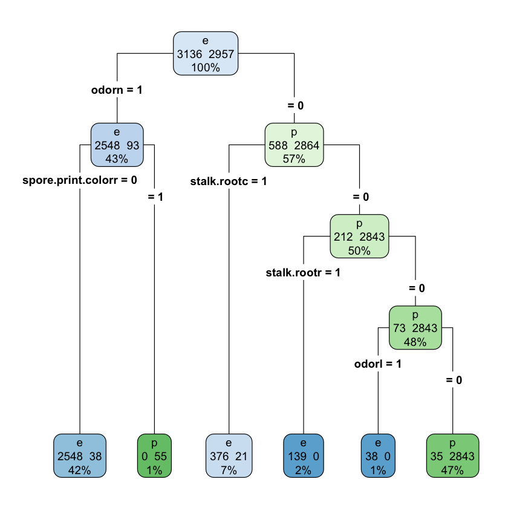

```r
rpart.plot(optTree, type = 4, extra = 101)
```

```r
tree_rules <- rpart.rules(optTree, style = "tallw", cover=TRUE)
print(tree_rules)
```

```
.outcome is 0.00 with cover 2% when
                 odorn is 0
                 stalk.rootc is 0
                 stalk.rootr is 1

.outcome is 0.00 with cover 1% when
                 odorn is 0
                 stalk.rootc is 0
                 stalk.rootr is 0
                 odorl is 1

.outcome is 0.01 with cover 42% when
                 odorn is 1
                 spore.print.colorr is 0

.outcome is 0.05 with cover 7% when
                 odorn is 0
                 stalk.rootc is 1

.outcome is 0.99 with cover 47% when
                 odorn is 0
                 stalk.rootc is 0
                 stalk.rootr is 0
                 odorl is 0

.outcome is 1.00 with cover 1% when
                 odorn is 1
                 spore.print.colorr is 1
```

Rules translation:

The rules heavily depend on odor, stalk.root, and spore.print.color

```r
# Inspect frequent antecedents
inspect(head(sort(rEclat_edible, by = "support"), 10))
inspect(head(sort(rEclat_poisonous, by = "support"), 10))
```

```
     lhs                          rhs              support confidence      lift itemset
[1]  {VeilType=partial}        => {Class=edible} 0.5179714  0.5179714 1.0000000  337643
[2]  {GillAttached=free,
      VeilColor=white}         => {Class=edible} 0.4943378  0.5079686 0.9806885  337641
[3]  {VeilColor=white}         => {Class=edible} 0.4943378  0.5068147 0.9784608  337644
[4]  {GillAttached=free}       => {Class=edible} 0.4943378  0.5074551 0.9796971  337645
[5]  {GillSize=broad}          => {Class=edible} 0.4825209  0.6985032 1.3485361  337648
[6]  {RingNumber=one}          => {Class=edible} 0.4529788  0.4914530 0.9488033  337646
[7]  {SurfaceAboveRing=smooth} => {Class=edible} 0.4480551  0.7032457 1.3576921  337649
[8]  {Odor=none}               => {Class=edible} 0.4194978  0.9659864 1.8649414  323695
[9]  {SurfaceBelowRing=smooth} => {Class=edible} 0.4185130  0.6888169 1.3298356  337650
[10] {GillSize=broad,
      SurfaceAboveRing=smooth} => {Class=edible} 0.4155588  0.9398664 1.8145139  337585
     lhs                     rhs                 support confidence     lift itemset
[1]  {VeilType=partial}   => {Class=poisonous} 0.4820286  0.4820286 1.000000  333394
[2]  {VeilColor=white}    => {Class=poisonous} 0.4810438  0.4931853 1.023145  333395
[3]  {GillAttached=free}  => {Class=poisonous} 0.4798129  0.4925449 1.021817  333396
[4]  {GillAttached=free,
      RingNumber=one}     => {Class=poisonous} 0.4687346  0.5219298 1.082778  333389
[5]  {RingNumber=one}     => {Class=poisonous} 0.4687346  0.5085470 1.055014  333397
[6]  {GillSpace=close,
      VeilColor=white}    => {Class=poisonous} 0.4682422  0.5746224 1.192092  333380
[7]  {GillSpace=close}    => {Class=poisonous} 0.4682422  0.5584263 1.158492  333398
[8]  {VeilColor=white,
      RingNumber=one}     => {Class=poisonous} 0.4677499  0.5214050 1.081689  333388
[9]  {GillAttached=free,
      GillSpace=close}    => {Class=poisonous} 0.4660266  0.5734626 1.189686  333381
[10] {GillSpace=close,
      VeilColor=white,
      RingNumber=one}     => {Class=poisonous} 0.4549483  0.5892857 1.222512  333373
```

```r
table(mushrooms$odor, mushrooms$class)
```

```
       e    p
  a  400    0
  c    0  192
  f    0 2160
  l  400    0
  m    0   36
  n 3408  120
  p    0  256
  s    0  576
  y    0  576
```

### Analysis of Odor in both methods

The variable odor plays a central role in both the classification tree and the association rules due to its strong correlation with the target variable.

- In the classification tree

  The tree identifies Odor as the most discriminative variable, using it as the primary split to differentiate between edible and poisonous mushrooms. However, Odor=n (no odor) introduces some ambiguity, as it is associated with both edible (3408 cases) and poisonous (120 cases) mushrooms. The tree resolves this by combining Odor=n with other variables, such as SporePrintColor, to distinguish between the two classes. This hierarchical prioritization ensures that the tree selects variables with the highest discriminatory ability at each level.
- In the association rules

  In the Eclat association rules, Odor frequently appears as a key antecedent. For instance, the rule {Odor=none} => {Class=edible} has high confidence (96.6%) and lift (1.86), reinforcing its strong predictive power. However, unlike the tree, Eclat does not prioritize variables hierarchically. As a result, Odor is often combined with less discriminative variables, such as SurfaceAboveRing, which may limit its predictive utility compared to the tree model. This methodological difference explains why Odor=n is interpreted differently: Eclat focuses on its global frequency, associating it primarily with edibility, while the tree considers its interactions with other variables to account for the poisonous cases.

### Analysis of GillSize and SurfaceAboveRing

Variables like GillSize and SurfaceAboveRing frequently appear as antecedents in the association rules, particularly for edible mushrooms. For example, {GillSize=broad} => {Class=edible} shows high confidence and lift, indicating a strong correlation in the dataset.

However, these variables do not appear in the classification tree, likely because they are less discriminative when compared to Odor or SporePrintColor. While GillSize and SurfaceAboveRing have strong global associations with edibility, their predictive power diminishes when considered hierarchically with other variables. This highlights a key difference between the methods:

- Association rules capture frequent patterns in the data.
- The tree focuses on variables with the highest discriminatory ability for specific contexts.

### Conclusion

While both methods highlight Odor as a key variable, their antecedents do not fully coincide. The classification tree prioritizes variables like SporePrintColor for their discriminatory power, whereas Eclat emphasizes frequently occurring combinations, such as {GillSize=broad} or {SurfaceAboveRing=smooth}. These differences reflect the distinct goals of the methods: the tree optimizes for predictive accuracy, while association rules uncover descriptive patterns in the dataset.